# Reference label transfer exploration for SCPCS000176

Maud PLASCHKA

2024-08-07

## Introduction

The aim is to find an appropriate reference to perform label transfer as a step of the annotation of the Wilms tumor dataset for the sample `param$sample_id` =

```r
params$sample_id
```

```
## [1] "SCPCS000176"
```

The use of the right reference is crucial. It is recommended that the cell types in the reference is representative to the cell types to be annotated in the query.

Wilms tumors can contain up to three histologies that resemble fetal kidney: blastema, stroma, and epithelia [1-2]. Because of their histological similarity to fetal kidneys, Wilms tumors are thought to arise from developmental derangements in embryonic renal progenitors.

We thus decided to test and compare fetal (kidney) references that could be use in the analysis module. You can find below the three workflow/reference that we plan to test.

### Human fetal kidney atlas Stewart et al.

We first wanted to try the human fetal kidney atlas to transfer label into the Wilms tumor samples using azimuth. You can find more about the human kidney atlas here: https://www.kidneycellatlas.org/ [3]

Using this reference, we test two workflows for label transfer:

- `Azimuth v5`,
- `Seurat v4` as described here https://satijalab.org/seurat/articles/integration_mapping.html#cell-type-classification-using-an-integrated-reference

### Azimuth Human fetal atlas Cao et al.

Azimuth also provide a human fetal atlas as a reference [4].

The data can be found on Zenodo: https://zenodo.org/records/4738021#.YJIW4C2ZNQI

The reference contain cells from 15 organs including kidney from fetal samples. Here we will use `Azimuth` to transfer labels from the reference.

In this notebook, we will test the human fetal Azimuth reference from Cao et al. using Azimuth . ##########################################################################################################

### Packages

Load required packages in the following chunk, if needed. Do not install packages here; only load them with the `library()` function.

```r
library(SingleCellExperiment)

library("Seurat")
library(sctransform)
library(Azimuth)
library(SeuratData)

library(assertthat)
library(viridis)
library(SCpubr)
library(tidyverse)
library(patchwork)

set.seed(params$seed)
```

### Base directories

```r
# The base path for the OpenScPCA repository, found by its (hidden) .git directory
repository_base <- rprojroot::find_root(rprojroot::is_git_root)

# The current data directory, found within the repository base directory
data_dir <- file.path(repository_base, "data", params$current, params$scpca_project_id)

# The path to this module
module_base <- file.path(repository_base, "analyses", "cell-type-wilms-tumor-06")
```

### Input files

#### Reference

We install and load the reference using `Azimuth`.

```r
#Check the names of the Azimuth available data and reference
AvailableData()
```

|  | Dataset | Version | Summary | species | system | ncells | tech | seurat | default.dataset | disk.datasets | other.datasets | notes | Installed | InstalledVersion |
| --- | --- | --- | --- | --- | --- | --- | --- | --- | --- | --- | --- | --- | --- | --- |
| adiposeref.SeuratData | adiposeref |  | Azimuth Reference: adipose | human | adipose | 160075 | scRNA-seq and sNuc-seq | NA | NA | NA | NA | NA | FALSE |  |
| bmcite.SeuratData | bmcite |  | 30k Bone Marrow Cells | human | bone marrow | 30672 | NA | 3.2.2 | NA | NA | NA | NA | FALSE |  |
| bonemarrowref.SeuratData | bonemarrowref |  | Azimuth Reference: bonemarrow | human | bonemarrow | 297627 | 10x v2 | NA | NA | NA | NA | NA | FALSE |  |
| cbmc.SeuratData | cbmc |  | scRNAseq and 13-antibody sequencing of CBMCs | human | CBMC (cord blood) | 8617 | CITE-seq | 3.1.4 | raw | processed | NA | NA | FALSE |  |
| celegans.embryo.SeuratData | celegans.embryo |  | 6k C. elegans embryos from Packer and Zhu et al (2019) | C. elegans | embryo | 6188 | NA | NA | raw | NA | NA | NA | FALSE |  |
| fetusref.SeuratData | fetusref |  | Azimuth Reference: fetus | human | fetus | 377456 | NA | NA | NA | NA | NA | NA | TRUE |  |
| hcabm40k.SeuratData | hcabm40k |  | 40,000 Cells From the Human Cell Atlas ICA Bone Marrow Dataset | human | bone marrow | 40000 | 10x v2 | NA | raw | NA | NA | NA | FALSE |  |
| heartref.SeuratData | heartref |  | Azimuth Reference: heart | human | heart | 656509 | scRNA-seq and sNuc-seq | NA | NA | NA | NA | NA | FALSE |  |
| humancortexref.SeuratData | humancortexref |  | Azimuth Reference: humancortex | human | motor cortex | 76533 | NA | NA | NA | NA | NA | NA | FALSE |  |
| ifnb.SeuratData | ifnb |  | IFNB-Stimulated and Control PBMCs | human | PBMC | 13999 | 10x v1 | NA | raw | NA | processed | NA | FALSE |  |

[output cut: 14 more lines]

```r
# Install the fetal reference
InstallData("fetusref")
ref <- SeuratData::LoadData("fetusref", type = "azimuth")
```

#### Query

In this notebook, we test the label transfer from the azimuth fetal atlas (reference) to the Wilms tumor sample defined in `params$sample_id` from the Wilms tumor dataset `param$scpca_project_id`

```r
filelist <- list.files(data_dir, full.names = TRUE)

# select the 40 Wilms tumor single nucleus folders only
filedir <- filelist[grepl(params$sample_id, filelist)]
```

### Output file

Reports will be saved in the `notebook/00-reference` directory.

### Load and pre-process the query data

```r
file <- list.files(filedir)
file <- file[grepl("_processed.rds", file)]

# open the processed rds object
sce <- readRDS(paste0(filedir, "/", file))
```

```r
# convert to seurat
srat <- CreateSeuratObject(counts = counts(sce),
                                    assay = "RNA",
                                    project = params$sample_id
                           )

# convert colData and rowData to data.frame for use in the Seurat object
cell_metadata <- as.data.frame(colData(sce))
row_metadata <- as.data.frame(rowData(sce))

# add cell metadata (colData) from SingleCellExperiment to Seurat
srat@meta.data <- cell_metadata

# add row metadata (rowData) from SingleCellExperiment to Seurat
srat[["RNA"]]@meta.data <- row_metadata

# add metadata from SingleCellExperiment to Seurat
srat@misc <- metadata(sce)


# Normalization
options(future.globals.maxSize= 8912896000000)
srat <- SCTransform(srat, verbose = F, conserve.memory = TRUE)

# dimensionality reduction
srat <- RunPCA(srat, verbose = F)
srat <- RunUMAP(srat, dims = 1:50, verbose = F)

# clustering
srat    <- FindNeighbors(srat, dims = 1:50, verbose = F)
srat    <- FindClusters(srat, verbose = T)
```

```
## Modularity Optimizer version 1.3.0 by Ludo Waltman and Nees Jan van Eck
##
## Number of nodes: 1483
## Number of edges: 69118
##
## Running Louvain algorithm...
## Maximum modularity in 10 random starts: 0.7573
## Number of communities: 8
## Elapsed time: 0 seconds
```

### Label transfer from fetal kidney reference using Azimuth

```r
DefaultAssay(srat) <- "RNA"
s <- RunAzimuth(srat, reference ="fetusref" )
```

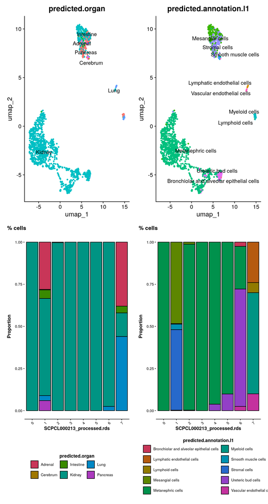

```r
d1 <- DimPlot(s, reduction = "umap", dims = c(1,2), group.by = "predicted.organ", label = TRUE, repel = TRUE) + NoLegend()
d2 <- DimPlot(s, reduction = "umap", dims = c(1,2), group.by = "predicted.annotation.l1", label = TRUE, repel = TRUE) + NoLegend()
d3 <- DimPlot(s, reduction = "umap", dims = c(1,2), group.by = "predicted.annotation.l2", label = TRUE, repel = TRUE) + NoLegend()

f1 <- SCpubr::do_BarPlot(sample = s,
                         group.by = "predicted.organ",
                         split.by = "seurat_clusters",
                         position = "fill",
                         font.size = 10,
                         legend.ncol = 4) +
                         ggtitle("% cells")+
                         xlab(file)

f2 <- SCpubr::do_BarPlot(sample = s,
                         group.by = "predicted.annotation.l1",
                         split.by = "seurat_clusters",
                         position = "fill",
                         font.size = 10,
                         legend.ncol = 2) +
                         ggtitle("% cells")+
                         xlab(file)

f3 <- SCpubr::do_BarPlot(sample = s,
                         group.by = "predicted.annotation.l2",
                         split.by = "seurat_clusters",
                         position = "fill",
                         font.size = 10,
                         legend.ncol = 2) +
                         ggtitle("% cells")+
                         xlab(file)

((d1/f1) | (d2/f2) )
```

## References

- [1] https://www.ncbi.nlm.nih.gov/books/NBK373356/
- [2] https://www.ncbi.nlm.nih.gov/pmc/articles/PMC9915828/
- [3] https://www.science.org/doi/10.1126/science.aat5031
- [4] https://www.science.org/doi/10.1126/science.aba7721